# R Notebook

## Mini-Projet

Les fonctions se trouvent dans mesfonctions.R

Rq: les reponses sont pour a = 1, b = 2.5

```r
load('projectData.Rdata')
source('mesfonctions.R')
source('evalTools.R')
```

## Interpolation Polynomiale

Q1.a

Noeuds Equidistants

Degre trop petit : Pour un degre trop petit, l’interpolation est aberrante

```
  [1] 0.1666667 0.1880931 0.2090822 0.2296340 0.2497486 0.2694259 0.2886659 0.3074686 0.3258341
 [10] 0.3437623 0.3612532 0.3783069 0.3949233 0.4111024 0.4268442 0.4421488 0.4570160 0.4714461
 [19] 0.4854388 0.4989943 0.5121125 0.5247934 0.5370370 0.5488434 0.5602125 0.5711443 0.5816389
 [28] 0.5916962 0.6013162 0.6104989 0.6192444 0.6275526 0.6354235 0.6428571 0.6498535 0.6564126
 [37] 0.6625344 0.6682190 0.6734663 0.6782763 0.6826490 0.6865845 0.6900826 0.6931436 0.6957672
 [46] 0.6979536 0.6997027 0.7010145 0.7018890 0.7023263 0.7023263 0.7018890 0.7010145 0.6997027
 [55] 0.6979536 0.6957672 0.6931436 0.6900826 0.6865845 0.6826490 0.6782763 0.6734663 0.6682190
 [64] 0.6625344 0.6564126 0.6498535 0.6428571 0.6354235 0.6275526 0.6192444 0.6104989 0.6013162
 [73] 0.5916962 0.5816389 0.5711443 0.5602125 0.5488434 0.5370370 0.5247934 0.5121125 0.4989943
 [82] 0.4854388 0.4714461 0.4570160 0.4421488 0.4268442 0.4111024 0.3949233 0.3783069 0.3612532
 [91] 0.3437623 0.3258341 0.3074686 0.2886659 0.2694259 0.2497486 0.2296340 0.2090822 0.1880931
[100] 0.1666667
```

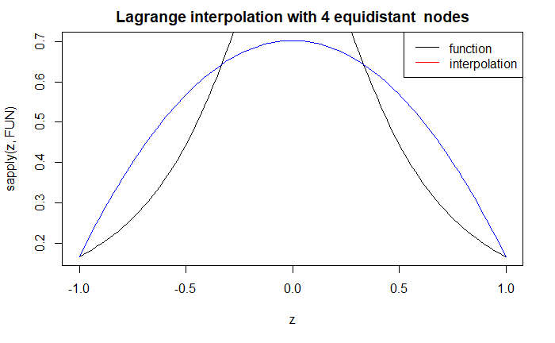

```r
interpolLagrange(3,-1,1,100,'equi',runge,TRUE)
```

Degre trop eleve : Pour un degre trop eleve, les erreurs deviennent trop importantes aux extremites

```
  [1]  0.1666667 12.5495604 -0.8721930  0.2219157  0.1971458  0.1969215  0.2058556  0.2134143  0.2215056
 [10]  0.2300393  0.2390137  0.2484662  0.2584243  0.2689184  0.2799806  0.2916443  0.3039447  0.3169178
 [19]  0.3306011  0.3450327  0.3602514  0.3762958  0.3932039  0.4110123  0.4297553  0.4494635  0.4701621
 [28]  0.4918699  0.5145962  0.5383390  0.5630817  0.5887901  0.6154088  0.6428571  0.6710256  0.6997715
 [37]  0.7289157  0.7582392  0.7874819  0.8163418  0.8444770  0.8715099  0.8970346  0.9206275  0.9418605
 [46]  0.9603175  0.9756122  0.9874068  0.9954296  0.9994901  0.9994901  0.9954296  0.9874068  0.9756122
 [55]  0.9603175  0.9418605  0.9206275  0.8970346  0.8715099  0.8444770  0.8163418  0.7874819  0.7582392
 [64]  0.7289157  0.6997715  0.6710256  0.6428571  0.6154088  0.5887901  0.5630817  0.5383390  0.5145962
 [73]  0.4918699  0.4701621  0.4494634  0.4297553  0.4110123  0.3932039  0.3762958  0.3602514  0.3450327
 [82]  0.3306011  0.3169176  0.3039440  0.2916438  0.2799791  0.2689179  0.2584302  0.2484672  0.2390403
 [91]  0.2301307  0.2216345  0.2141760  0.2071516  0.2004690  0.2042260  0.2417083 -0.8990575 13.3449074
[100]  0.3240025
```

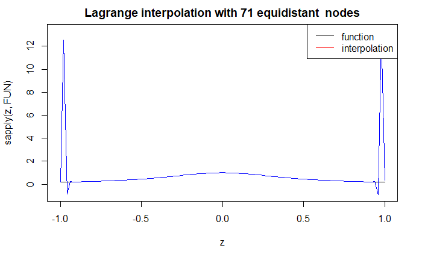

```r
interpolLagrange(70,-1,1,100,'equi',runge,TRUE)
```

Noeuds Tchebychev

Degre trop petit : Pour un degre trop petit, l’interpolation est abherrante

```
  [1] 0.1095890 0.1315046 0.1529729 0.1739940 0.1945678 0.2146943 0.2343736 0.2536057 0.2723904
 [10] 0.2907280 0.3086182 0.3260612 0.3430570 0.3596055 0.3757067 0.3913607 0.4065674 0.4213269
 [19] 0.4356391 0.4495040 0.4629217 0.4758922 0.4884154 0.5004913 0.5121200 0.5233014 0.5340355
 [28] 0.5443224 0.5541621 0.5635545 0.5724996 0.5809975 0.5890481 0.5966514 0.6038076 0.6105164
 [37] 0.6167780 0.6225923 0.6279594 0.6328792 0.6373518 0.6413771 0.6449552 0.6480860 0.6507695
 [46] 0.6530058 0.6547948 0.6561366 0.6570311 0.6574783 0.6574783 0.6570311 0.6561366 0.6547948
 [55] 0.6530058 0.6507695 0.6480860 0.6449552 0.6413771 0.6373518 0.6328792 0.6279594 0.6225923
 [64] 0.6167780 0.6105164 0.6038076 0.5966514 0.5890481 0.5809975 0.5724996 0.5635545 0.5541621
 [73] 0.5443224 0.5340355 0.5233014 0.5121200 0.5004913 0.4884154 0.4758922 0.4629217 0.4495040
 [82] 0.4356391 0.4213269 0.4065674 0.3913607 0.3757067 0.3596055 0.3430570 0.3260612 0.3086182
 [91] 0.2907280 0.2723904 0.2536057 0.2343736 0.2146943 0.1945678 0.1739940 0.1529729 0.1315046
[100] 0.1095890
```

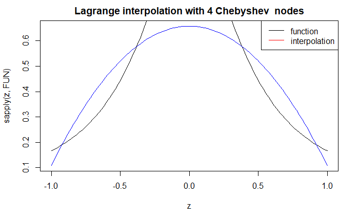

```r
interpolLagrange(3,-1,1,100,'cheby',runge,TRUE)
```

Degre trop eleve : Pour un degre trop eleve, les erreurs deviennent trop importantes aux extremites

```
  [1]  0.53013973 -1.70678089  0.57822010  0.22800670 -0.01894499  0.22834524  0.22941113  0.17767156
  [9]  0.18654851  0.23696209  0.22384385  0.23055351  0.26231185  0.26775512  0.27751508  0.29083624
 [17]  0.30336679  0.31643800  0.33076481  0.34523691  0.36017607  0.37627244  0.39321923  0.41101771
 [25]  0.42974077  0.44945962  0.47015221  0.49187100  0.51459697  0.53833794  0.56308152  0.58878964
 [33]  0.61540890  0.64285678  0.67102566  0.69977148  0.72891560  0.75823924  0.78748191  0.81634183
 [41]  0.84447699  0.87150987  0.89703460  0.92062746  0.94186047  0.96031746  0.97561218  0.98740681
 [49]  0.99542962  0.99949011  0.99949011  0.99542962  0.98740681  0.97561218  0.96031746  0.94186047
 [57]  0.92062747  0.89703460  0.87150987  0.84447699  0.81634183  0.78748192  0.75823921  0.72891566
 [65]  0.69977153  0.67102561  0.64285714  0.61540877  0.58879010  0.56308170  0.53833901  0.51459624
 [73]  0.49186992  0.47016214  0.44946345  0.42975533  0.41101233  0.39320388  0.37629578  0.36025142
 [81]  0.34503274  0.33060109  0.31691780  0.30394468  0.29164435  0.27998057  0.26891840  0.25842430
 [89]  0.24846626  0.23901380  0.23003802  0.22151155  0.21340853  0.20570457  0.19837672  0.19140335
 [97]  0.18476417  0.17844008  0.17241319  0.16666667
```

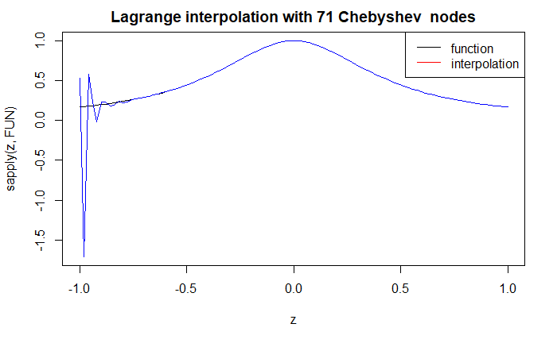

```r
interpolLagrange(70,-1,1,100,'cheby',runge,TRUE)
```

Q1.b

Pour les parametres suivants, l’interpolateur est satisfaisant

```
  [1] 0.1663427 0.1727473 0.1784915 0.1844858 0.1910382 0.1981588 0.2057468 0.2136940 0.2219335
 [10] 0.2304540 0.2392935 0.2485245 0.2582362 0.2685187 0.2794505 0.2910920 0.3034825 0.3166418
 [19] 0.3305749 0.3452777 0.3607441 0.3769719 0.3939683 0.4117526 0.4303575 0.4498281 0.4702177
 [28] 0.4915835 0.5139789 0.5374461 0.5620079 0.5876591 0.6143598 0.6420284 0.6705376 0.6997114
 [37] 0.7293246 0.7591050 0.7887369 0.8178678 0.8461165 0.8730830 0.8983594 0.9215420 0.9422433
 [46] 0.9601046 0.9748068 0.9860811 0.9937175 0.9975724 0.9975724 0.9937175 0.9860811 0.9748068
 [55] 0.9601046 0.9422433 0.9215420 0.8983594 0.8730830 0.8461165 0.8178678 0.7887369 0.7591050
 [64] 0.7293246 0.6997114 0.6705376 0.6420284 0.6143598 0.5876591 0.5620079 0.5374461 0.5139789
 [73] 0.4915835 0.4702177 0.4498281 0.4303575 0.4117526 0.3939683 0.3769719 0.3607441 0.3452777
 [82] 0.3305749 0.3166418 0.3034825 0.2910920 0.2794505 0.2685187 0.2582362 0.2485245 0.2392935
 [91] 0.2304540 0.2219335 0.2136940 0.2057468 0.1981588 0.1910382 0.1844858 0.1784915 0.1727473
[100] 0.1663427
```

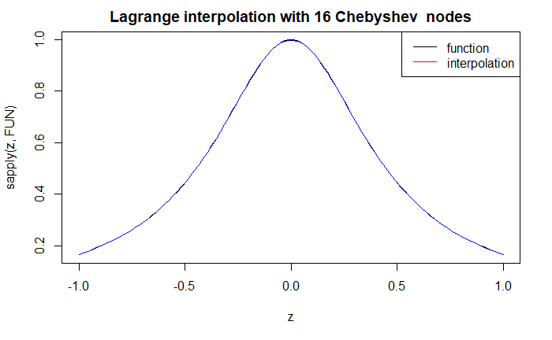

```r
interpolLagrange(15,-1,1,100,'cheby',runge,TRUE)
```

Q1.c

Noeuds equidistants

On conjecture que le rang n sera inferieur a 50

```r
errorRank('equi')[1]
```

```
[1] 3
```

```r
#pour verifier la liste d'erreurs : erreurRank('equi')[2]
```

rang de la methode qui minimise l’erreur d’interpolation sur evalHeight : 3

Noeuds Tchebychev

```r
errorRank('cheby')[1]
```

```
[1] 36
```

```r
#pour verifier la liste d'erreurs : erreurRank('cheby')[2]
```

rang de la methode qui minimise l’erreur d’interpolation sur evalHeight : 36

Q2.a

```
      [,1]     [,2]     [,3]     [,4]     [,5]     [,6]     [,7]     [,8]     [,9]    [,10]    [,11]
f 3.225232 2.247033 2.034820 1.960487 1.933040 1.919725 1.913628 1.909683 1.908233 1.904579 1.900470
z 1.000000 1.011111 1.022222 1.033333 1.044444 1.055556 1.066667 1.077778 1.088889 1.100000 1.111111
     [,12]    [,13]    [,14]    [,15]    [,16]    [,17]    [,18]    [,19]    [,20]    [,21]    [,22]
f 1.894342 1.887343 1.877485 1.865602 1.852593 1.837437 1.819813 1.801022 1.781973 1.760711 1.738440
z 1.122222 1.133333 1.144444 1.155556 1.166667 1.177778 1.188889 1.200000 1.211111 1.222222 1.233333
     [,23]    [,24]    [,25]    [,26]    [,27]    [,28]    [,29]    [,30]    [,31]    [,32]    [,33]
f 1.717730 1.697160 1.677847 1.658761 1.642504 1.630215 1.621555 1.616230 1.617563 1.623985 1.638483
z 1.244444 1.255556 1.266667 1.277778 1.288889 1.300000 1.311111 1.322222 1.333333 1.344444 1.355556
     [,34]    [,35]    [,36]    [,37]    [,38]    [,39]    [,40]    [,41]    [,42]    [,43]    [,44]
f 1.660598 1.689168 1.727308 1.777603 1.836313 1.896710 1.975642 2.063615 2.154617 2.253570 2.365552
z 1.366667 1.377778 1.388889 1.400000 1.411111 1.422222 1.433333 1.444444 1.455556 1.466667 1.477778
     [,45]    [,46]    [,47]    [,48]    [,49]    [,50]    [,51]    [,52]    [,53]    [,54]    [,55]
f 2.483563 2.595126 2.708435 2.833344 2.955705 3.067389 3.172474 3.275804 3.368815 3.439044 3.504839
z 1.488889 1.500000 1.511111 1.522222 1.533333 1.544444 1.555556 1.566667 1.577778 1.588889 1.600000
     [,56]    [,57]    [,58]    [,59]    [,60]    [,61]    [,62]    [,63]    [,64]    [,65]    [,66]
f 3.557202 3.589365 3.607361 3.610550 3.600173 3.578939 3.549458 3.512190 3.475377 3.443016 3.415735
z 1.611111 1.622222 1.633333 1.644444 1.655556 1.666667 1.677778 1.688889 1.700000 1.711111 1.722222
     [,67]    [,68]    [,69]    [,70]    [,71]    [,72]    [,73]    [,74]    [,75]    [,76]    [,77]
f 3.401411 3.404129 3.426505 3.470290 3.543964 3.642332 3.758064 3.902506 4.063440 4.232159 4.398450
z 1.733333 1.744444 1.755556 1.766667 1.777778 1.788889 1.800000 1.811111 1.822222 1.833333 1.844444
     [,78]    [,79]    [,80]    [,81]    [,82]    [,83]    [,84]    [,85]    [,86]    [,87]    [,88]
f 4.573146 4.734684 4.860769 4.972603 5.043394 5.071803 5.068540 5.020172 4.938299 4.835635 4.718280
z 1.855556 1.866667 1.877778 1.888889 1.900000 1.911111 1.922222 1.933333 1.944444 1.955556 1.966667
     [,89]    [,90]    [,91]    [,92]    [,93]    [,94]    [,95]    [,96]    [,97]    [,98]    [,99]
f 4.590194 4.472154 4.386272 4.326587 4.310304 4.334867 4.402019 4.499787 4.629342 4.765126 4.876251
z 1.977778 1.988889 2.000000 2.011111 2.022222 2.033333 2.044444 2.055556 2.066667 2.077778 2.088889
    [,100]   [,101]   [,102]   [,103]   [,104]   [,105]   [,106]   [,107]   [,108]   [,109]   [,110]
f 4.969031 5.021093 4.998103 4.928538 4.784821 4.590685 4.378666 4.153400 3.939694 3.771733 3.671101
z 2.100000 2.111111 2.122222 2.133333 2.144444 2.155556 2.166667 2.177778 2.188889 2.200000 2.211111
    [,111]   [,112]   [,113]   [,114]   [,115]   [,116]   [,117]   [,118]   [,119]   [,120]   [,121]
f 3.641173 3.684474 3.781845 3.910515 4.039410 4.141934 4.179431 4.131481 3.993750 3.779928 3.524623
z 2.222222 2.233333 2.244444 2.255556 2.266667 2.277778 2.288889 2.300000 2.311111 2.322222 2.333333
    [,122]   [,123]   [,124]   [,125]   [,126]   [,127]   [,128]   [,129]   [,130]   [,131]   [,132]
f 3.269575 3.035253 2.877705 2.835742 2.876198 3.026986 3.200477 3.361790 3.462316 3.459869 3.337813
z 2.344444 2.355556 2.366667 2.377778 2.388889 2.400000 2.411111 2.422222 2.433333 2.444444 2.455556
    [,133]   [,134]   [,135]   [,136]
f 3.122644 2.829730 2.548628 2.356127
z 2.466667 2.477778 2.488889 2.500000
```

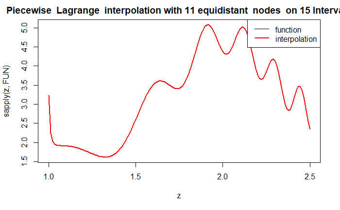

```r
piecewiseInterpol(10,15,1,2.5,10,"equi",evalHeight,TRUE)
```

Q2.b

```r
errorRank2(80)
```

```
[1] "24"    "cheby"
```

on trouve une erreur minimale pour

n = 24 noeuds

de type = ‘cheby’

neval = 80 intervalles

## Partie II : Methodes de quadrature (ouvrir Script-partie2.R)

Q2.1.a

Une premiere estimation de I est 4.824887

```r
simpsonInt(1,2.5,evalHeight,100)
```

```
[1] 4.824887
```

L’erreur a posteriori est d’ordre 10**(-5)

```r
evalErrSimpson(evalHeight,1,2.5,100)
```

```
[1] 2.021108e-05 4.824584e+00
```

Q2.1.b.i

41 evaluations nous donnent un budget de 20 sous-intervalles d’integration

Q2.1.b.ii

```r
evalErrSimpson(evalHeight,1,2.5,41)
```

```
[1] 5.049651e-05 4.824859e+00
```

Q2.2

Le M le plus petit qui garantit une précision a 10^-5 pres est M = 51

```r
M = evalErrSimpsonLoop(10**(-5))
M
```

```
[1] 51
```

I = 4.825031 a 10^-5 pres

```r
evalErrSimpson(evalHeight,1,2.5,M)
```

```
[1] 7.223002e-06 4.825031e+00
```

## Partie III : Methode de Richardson (ouvrir Script-partie3.R)

La methode de Richardson fonctionne en x = 0

Il faut utiliser une fonction qui translate evalHeight de 1 : evalHeightTranslate

Parametres : t=1. Pour t=1 l’erreur richardson est raisonablement proche de l’erreur naive

Parametres : delta=1/2. Pour delta = 1/2 l’erreur richardson est raisonablement proche de l’erreur naive

```r
n=15; t=1; delta = 1/2
```

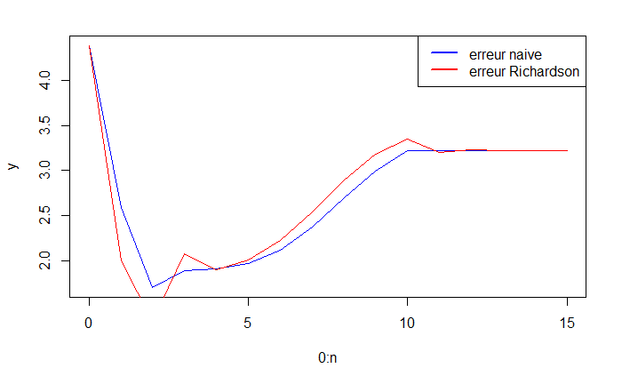

```r
plotRichardson(n,t,delta)
```